# Working prototype, phantom axial section of human thigh

W. Bauer

August 14, 2015

This describes a working prototype of a virtual axial section of a human thigh. The section is based on a public domain diagram from *Gray’s Anatomy* which is pictured below.

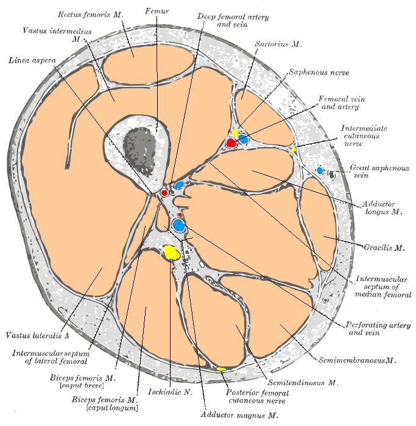

The phantom can be loaded and displayed as follows:

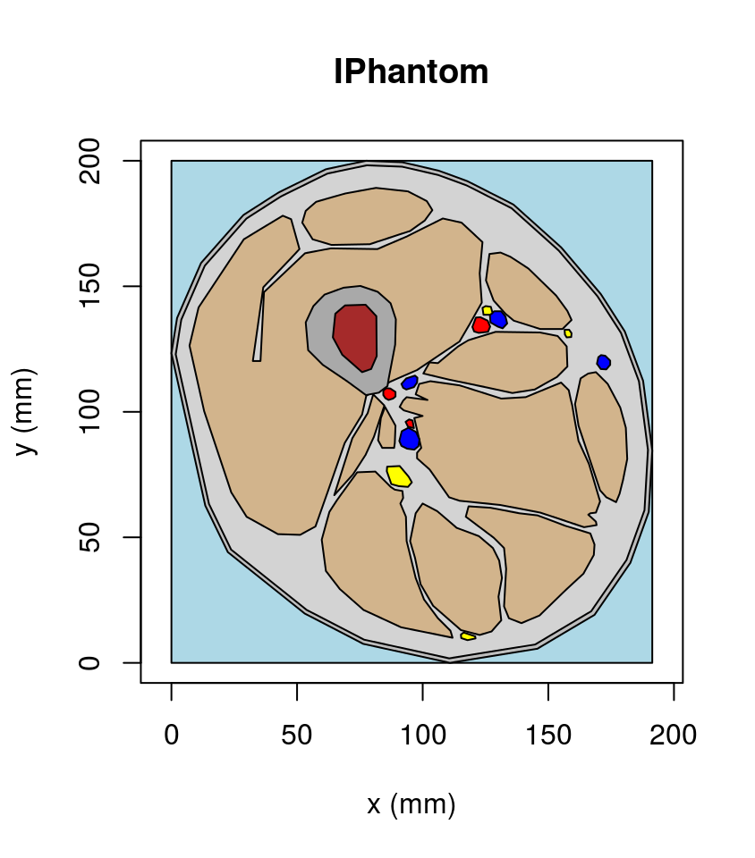

```r
source("../R/inkscape_utils.R")
phantom <- importIPhantom("../data/thigh_inkscape.csv")
plotIPhantom(phantom)
```

The phantom is meant for quick entré to the DVT use case presented at a recent meeting. The code is somewhat fragile and the phantom obviously simplified. At this writing the code lacks inline documentation, and this note is meant to partially fill that gap.

The phantom itself does not consist of pixels, but is a list of annotated polygons, where a polygon is an array of vertices. Polygonal vertices and edges can be easily discerned in the IPhantom figure above. (More detail is given at the end of this note.)

Rectangular sections of the phantom can, however, be selected and exported as matrices with integer entries identifying the type of tissue at a corresponding pixel. I’ll first illustrate how this is done and then explain how integer tissue types are associated with tissue names (e.g., Muscle, Vessel,) and acoustic properties.

A rectangular area is specified by a center point an orientation angle (in radians,) both estimated by eye, and a height which would generally be the width of a probe in millimeters. Referring to the IPhantom image above, a center point at `(100, 100)`, an orientation angle of $\pi/4$ radians, and a height of 30 mm might include the deep veins pictured in blue. The rectangle is computed as follows:

```r
rect <- computeRectangle(phantom, c(100,100), pi/4, 30)
```

Once computed, an overlay of the rectangle can be superimposed on the phantom image:

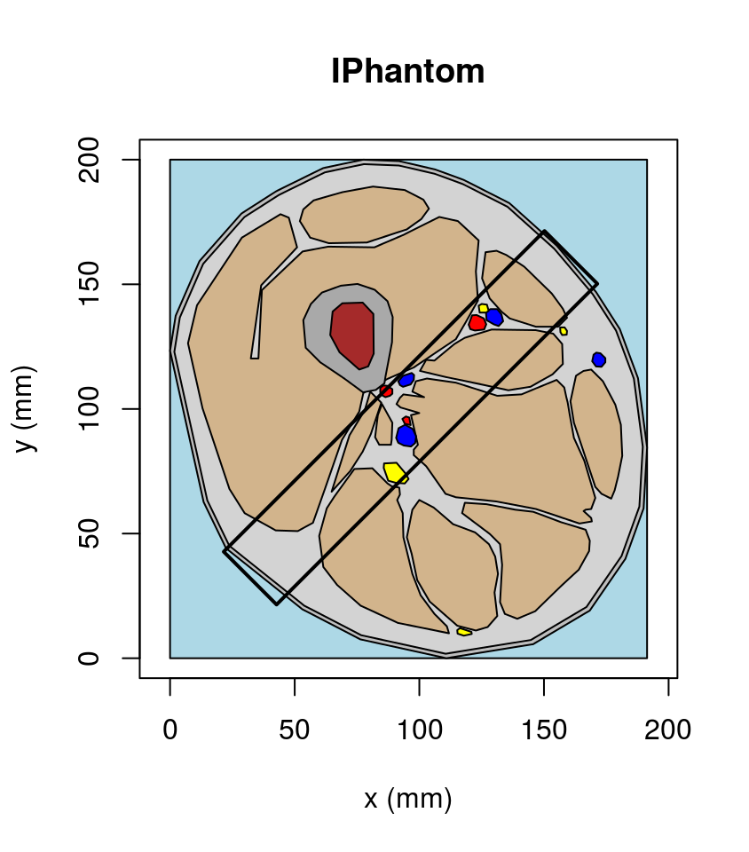

```r
plotIPhantom(phantom)
overlayRectangle(rect, lwd=2)
```

Utility `pixelate` will produce a pixelated image of the portion of the phantom within the rectangle. It requires a pixel size which in practice would be transducer spacing, (~0.23 mm,) but I’ll use 0.5 mm for illustration and convenience. Function `pixelatedImage` will display the result in gray scale.

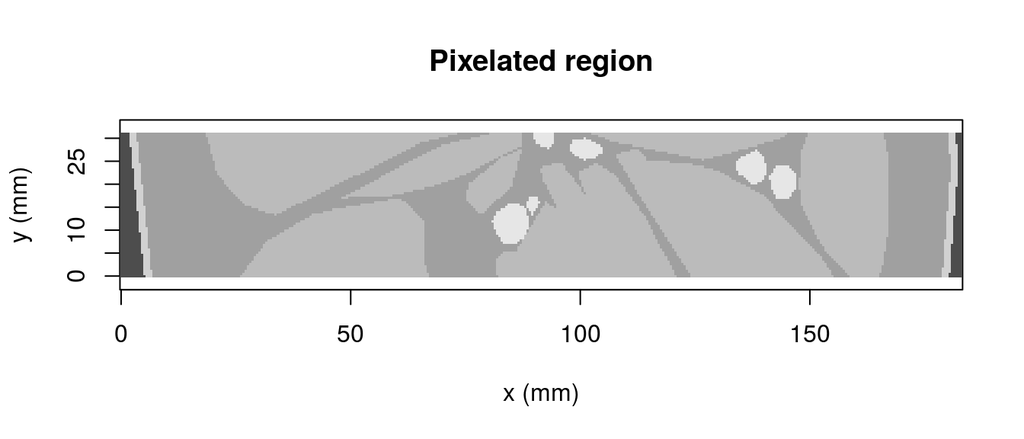

```r
img <- pixelate(phantom, rect, 0.5)
pixelatedImage(img, main="Pixelated region")
```

The image is essentially a matrix and, if desired, can be converted to Matlab (*.mat) binary file format using the R package `R.matlab`. (I can easily do this for any project member upon request.) Each entry in the matrix is a tissue ID, which corresponds to an entry in the ID column of the following table. For computer processing, the table can be read from the project’s `data/acoustic_properties_thigh.csv` spreadsheet.

| Tissue | ID | rho (kg/m<sup>3</sup>) | c (m/s) | Z |
| --- | --- | --- | --- | --- |
| PAA gel | 0 | 1103 | 1540 | 1698620 |
| White Matter | 3 | 1035 | 1562 | 1616670 |
| Fat | 4 | 928 | 1445 | 1340960 |
| Muscle | 5 | 1070 | 1585 | 1695950 |
| Muscle/Skin | 6 | 1110 | 1660 | 1842600 |
| Bone | 7 | 1610 | 2845 | 4580450 |
| Vessels | 8 | 1055 | 1584 | 1671120 |
| Around fat | 9 | 1000 | 1522 | 1522000 |
| Bone marrow | 11 | 1017 | 1540 | 1566180 |

### Phantom structure

Data on which the phantom is based are in the project’s `data/thigh_inkscape.csv` spreadsheet. Each record in that file consists primarily of manually traced outlines of major tissues based on the public domain diagram referenced earlier. Tracings were made with Inkscape, a free and open source scalable vector graphics editor.

(The prototype software described here can handle only the simplest of Inkscape’s path encoding constructs hence the caveat, “fragile.” E.g., NURBs are not handled.)

In detail, each record consists of 5 fields: layer, description, tissue, ID, path

- layer –a number indicating the order and color in which to draw the tissue. Also distinguishes different tissues of same type
- description –a string corresponding to the region’s label in Gray’s Anatomy
- tissue –a string naming the tissue type (e.g., Fat, Muscle, etc.)
- ID –a unique numerical ID encoding tissue type
- path –a string of coordinates which define the tissue’s outline in Inkscape SVG format.

When imported into R the format is similar. The overall structure, `phantom`, is a named list, and each record in the spreadsheet corresponds to an entry in that list. Each entry is, itself, a named list with fields matching those of the spreadsheet with one exception. The exception is that the spreadsheet’s `path` field is replaced by a `shape` array which represents the outline as an R polygon. All shapes are scaled to a common range (0 to 200 mm by default) so they are in correct proportion to one another.

The elements of `phantom` are named by the associated description field. E.g., the first 4 names are:

```r
names(phantom)[1:4]
```

```
## [1] "Boundary"           "Subcutaneous fat"   "Rectus Femoris"
## [4] "Vactus intermedius"
```

Each element has 5 fields as indicated above. Thus the first 4 fields of the “Vactus intermedius” muscle can be accessed, e.g., as

```r
phantom[["Vactus intermedius"]][1:4]
```

```
## $layer
## [1] 3
##
## $description
## [1] "Vactus intermedius"
##
## $tissue
## [1] "Muscle"
##
## $ID
## [1] 5
```

The shape field is more intelligible if plotted.

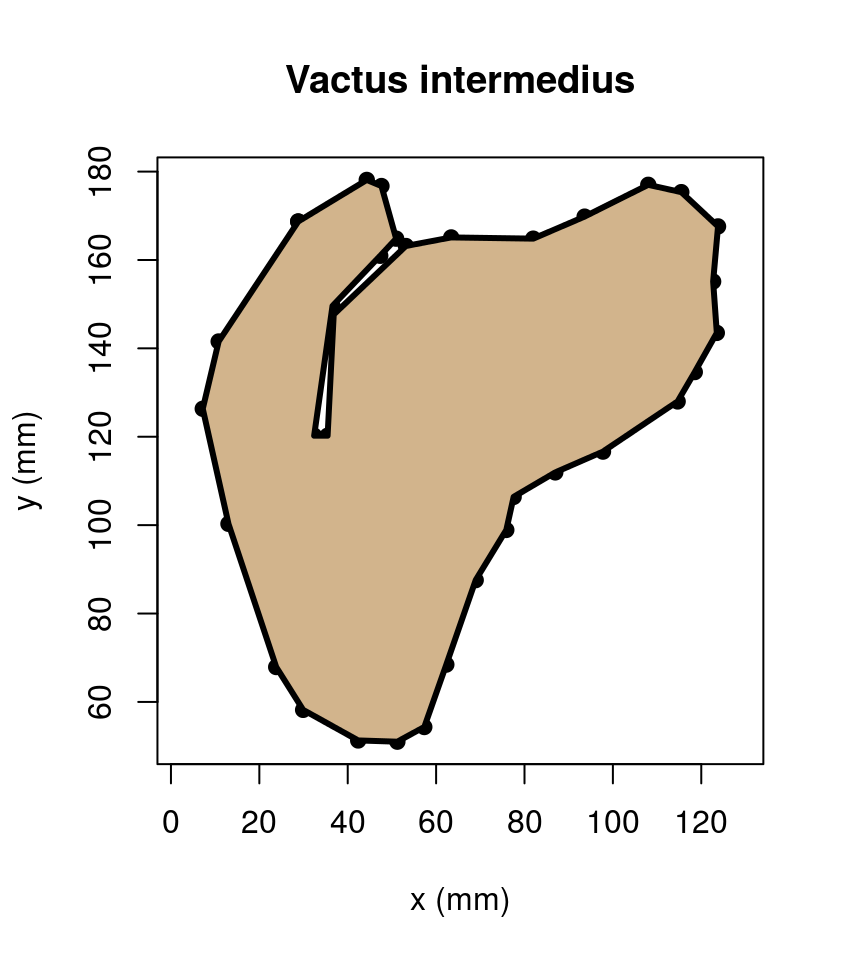

```r
shape <- phantom[["Vactus intermedius"]][["shape"]]
plot(shape[,1], shape[,2], xlab="x (mm)", ylab="y (mm)", main="Vactus intermedius", asp=1, pch=19)
polygon(shape[,1], shape[,2], lwd=3, col="tan")
```